# November_16.2023_rmd_github

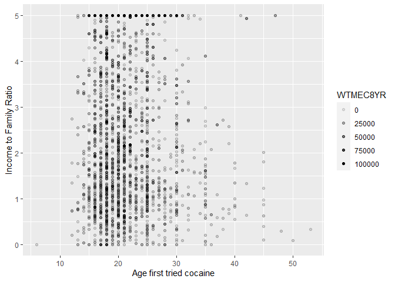

```r
################Relationship to Income:Family size ratio#######################

ggplot(table_nhanes_1, aes(x = DUQ260, y =
                             INDFMPIR, alpha = WTMEC8YR)) +
  geom_point(na.rm = TRUE) +
  scale_color_brewer(palette = "Set3") +
  ylab("Income to Family Ratio") +
  xlab("Age first tried cocaine")
```

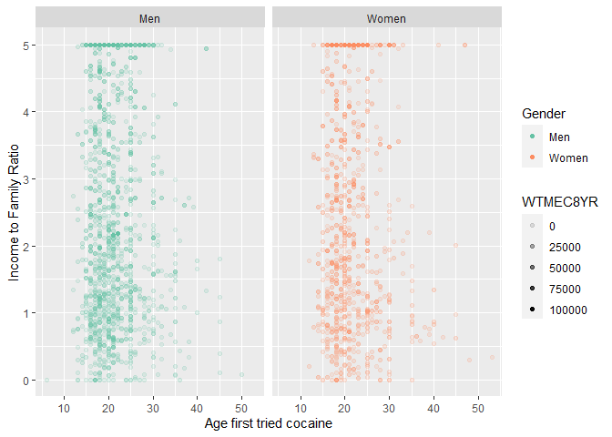

```r
ggplot(table_nhanes_1, aes(x = DUQ260, y =
                             INDFMPIR,
                           color = Gender,
                           alpha = WTMEC8YR)) +
  geom_point(na.rm = TRUE) +
  scale_color_brewer(palette = "Set2") +
  ylab("Income to Family Ratio") +
  xlab("Age first tried cocaine") +
  facet_wrap(~Gender)
```

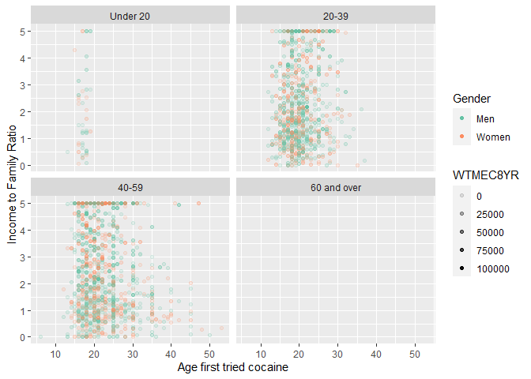

```r
ggplot(table_nhanes_1, aes(x = DUQ260, y =
                              INDFMPIR,
                            color = Gender,
                            alpha = WTMEC8YR)) +
  geom_point(na.rm = TRUE) +
  scale_color_brewer(palette = "Set2") +
  ylab("Income to Family Ratio") +
  xlab("Age first tried cocaine") +
  facet_wrap(~Age.Group)
```

**Description of above:** *Darker shading in dot plots indicates more heavily-weighted data points. Histogram “counts” are weighted.* Similar to marijuana, more men (n = 1298) than women (n = 795) reported age at first using cocaine. The overall average age at first using cocaine was ~21 yrs, about 4 years older than for marijuana, and was similar among men and women (total n = 2093). Similar to marijuana, average age at first trying cocaine decreased as age group decreased, implying that participants aged 20-59 tried cocaine at slightly older ages than under 20 participants.The histograms show that in these older age groups, age at first trying cocaine was skewed towards older age due to participants reporting trying cocaine for the first time in their 30’s and 40’s, similar to marijuana. Only 48 participants under 20 years reported age at first trying cocaine.The scatterplots do not demonstrate a clear relationship between income:family size ratio (lower ratios indicate greater poverty) and cocaine use by gender. Interestingly, there is a pattern in which many older participants (20-59 years) at higher poverty levels report older than average ages at first trying cocaine compared to participants with lower poverty levels.

```r
# C) Age first tried heroin (DUQ300)

table_nhanes_1 <- table_2011_2018 %>%
  mutate(DUQ300 = replace(DUQ300, DUQ300 >= 777, NA)) %>%
  #create factor variables
  mutate(# create indicator for overall summary
    table_nhanes_1 = 1,
    Year = factor(SDDSRVYR, labels = c("2011-2012", "2013-2014",
                                       "2015-2016", "2017-2018")),
    Gender = factor(RIAGENDR, labels=c("Men", "Women")),
    Age.Group = cut(RIDAGEYR, breaks=c(-Inf,19,39,59,Inf),
                    labels=c("Under 20", "20-39","40-59","60 and over")),
    # Generate 8-year MEC weight (Divide weight by 4 because we are
    #appending 4 survey cycles)
    # Note: using the MEC Exam Weights (WTMEC2YR), per the analytic notes
    #on the NHANES documentation
    WTMEC8YR = WTMEC2YR/4,
    # Define indicator for analysis population of interest: DUQ300 with a
    #valid age
    inAnalysis = (!is.na(DUQ300)))

NHANES_all_2 <- as_survey_design(table_nhanes_1, id=SDMVPSU, strata=SDMVSTRA,
                                 weights=WTMEC8YR, nest=TRUE)

NHANES_DUQ300 <- subset(NHANES_all_2, inAnalysis)
```

```r
# Weighted data descriptive statistics and visualizations

getSummary <- function(varformula, byformula, design){
  # Get mean, stderr, and unweighted sample size
  c <- svyby(varformula, byformula, design, unwtd.count )
  p <- svyby(varformula, byformula, design, svymean)
  outSum <- left_join(select(c,-se), p)
  outSum
}

# Get results (see output for all results tables and plots)

#DUQ300 weighted mean overall

getSummary(~DUQ300, ~table_nhanes_1, NHANES_DUQ300)
```

```
##   table_nhanes_1 counts   DUQ300        se
## 1              1    285 24.32627 0.8037168
```

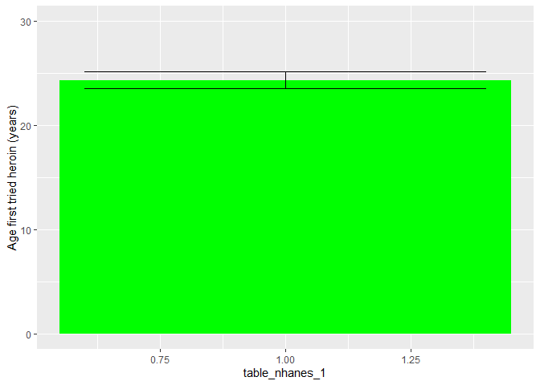

```r
out <- svyby(formula = ~DUQ300,
             by = ~table_nhanes_1,
             design = NHANES_DUQ300,
             FUN = svymean,
             na.rm = TRUE,
             keep.names = FALSE)

out_col <- mutate(out,
                  lower = DUQ300 - 1*se,
                  upper = DUQ300 + 1*se)

ggplot(out_col, aes(table_nhanes_1, DUQ300,
                    ymin = lower,
                    ymax = upper)) +
  geom_col(fill = "green") +
  ylab("Age first tried heroin (years)") +
  geom_errorbar(width = 0.8) +
  ylim(NA,30)
```

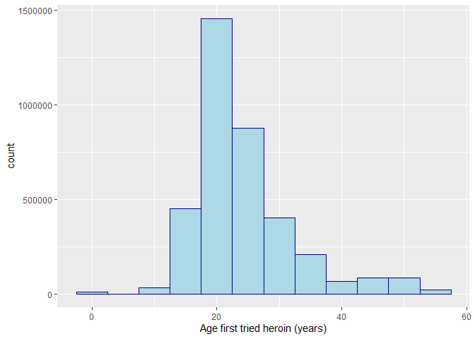

```r
ggplot(table_nhanes_1, aes(x = DUQ300, weight = WTMEC8YR)) +
  geom_histogram(binwidth = 5, color = "darkblue",
                 fill = "lightblue",
                 na.rm = TRUE)+
  xlab("Age first tried heroin (years)")
```

```r
# By Gender
getSummary(~DUQ300, ~Gender, NHANES_DUQ300)
```

```
##   Gender counts   DUQ300        se
## 1    Men    190 24.65102 1.0388882
## 2  Women     95 23.56931 0.7411713
```

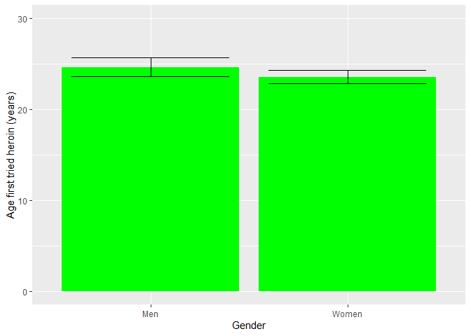

```r
out <- svyby(formula = ~DUQ300,
             by = ~Gender,
             design = NHANES_DUQ300,
             FUN = svymean,
             na.rm = TRUE,
             keep.names = FALSE)

out_col <- mutate(out,
                  lower = DUQ300 - 1*se,
                  upper = DUQ300 + 1*se)

ggplot(out_col, aes(x = Gender, y = DUQ300,
                    ymin = lower,
                    ymax = upper)) +
  geom_col(fill = "green") +
  ylab("Age first tried heroin (years)") +
  geom_errorbar(width = 0.8) +
  ylim(NA,30)
```

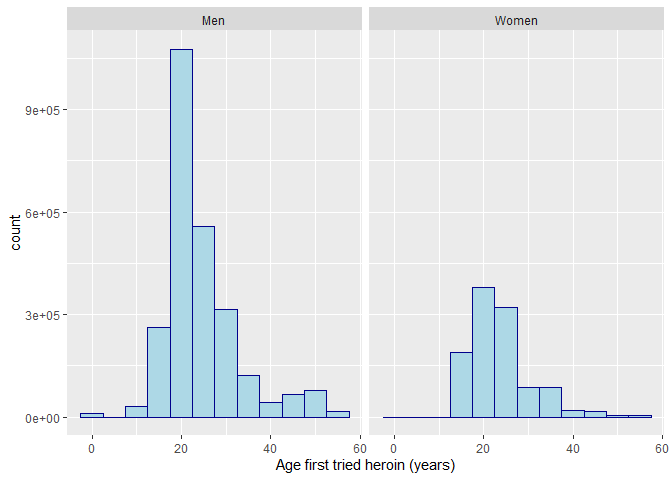

```r
ggplot(table_nhanes_1, aes(x = DUQ300, weight = WTMEC8YR)) +
  geom_histogram(binwidth = 5, color = "darkblue",
                 fill = "lightblue",
                 na.rm = TRUE) +
  facet_wrap(~Gender) +
  xlab("Age first tried heroin (years)")
```

```r
# By age
getSummary(~DUQ300, ~Age.Group, NHANES_DUQ300)
```

```
##   Age.Group counts   DUQ300        se
## 1  Under 20      1 18.00000 0.0000000
## 2     20-39    125 21.92782 0.5612027
## 3     40-59    159 26.83573 1.3221051
```

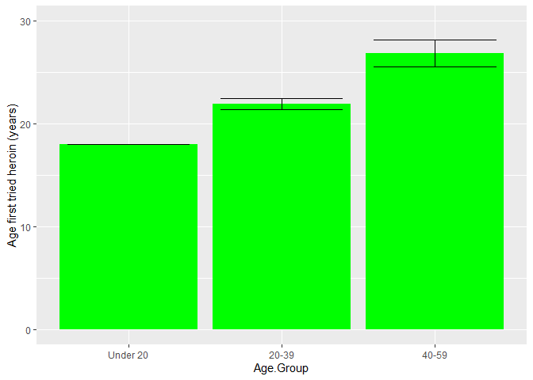

```r
out <- svyby(formula = ~DUQ300,
             by = ~Age.Group,
             design = NHANES_DUQ300,
             FUN = svymean,
             na.rm = TRUE,
             keep.names = FALSE)

out_col <- mutate(out,
                  lower = DUQ300 - 1*se,
                  upper = DUQ300 + 1*se)

ggplot(out_col, aes(x = Age.Group, y = DUQ300,
                    ymin = lower,
                    ymax = upper)) +
  geom_col(fill = "green") +
  ylab("Age first tried heroin (years)") +
  geom_errorbar(width = 0.8) +
  ylim(NA,30)
```

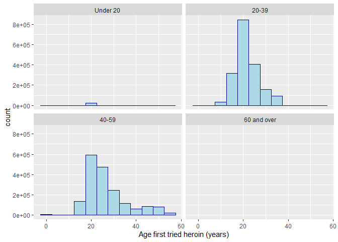

```r
ggplot(table_nhanes_1, aes(x = DUQ300, weight = WTMEC8YR)) +
  geom_histogram(binwidth = 5, color = "darkblue",
                 fill = "lightblue",
                 na.rm = TRUE) +
  facet_wrap(~Age.Group) +
  xlab("Age first tried heroin (years)")
```

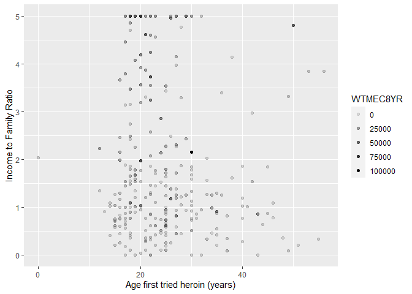

```r
################Relationship to Income:Family size ratio#######################

ggplot(table_nhanes_1, aes(x = DUQ300,
                           y = INDFMPIR,
                           alpha = WTMEC8YR)) +
  geom_point(na.rm = TRUE) +
  scale_color_brewer(palette = "Set2") +
  ylab("Income to Family Ratio") +
  xlab("Age first tried heroin (years)")
```

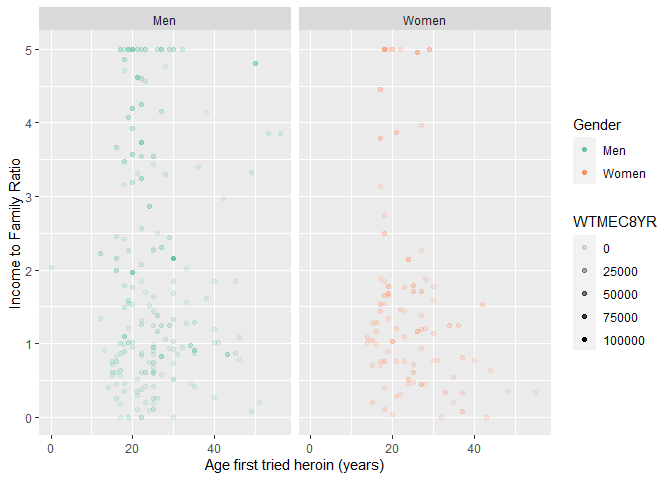

```r
ggplot(table_nhanes_1, aes(x = DUQ300,
                           y = INDFMPIR,
                                     color = Gender,
                                     alpha = WTMEC8YR)) +
  geom_point(na.rm = TRUE) +
  scale_color_brewer(palette = "Set2") +
  ylab("Income to Family Ratio") +
  xlab("Age first tried heroin (years)") +
  facet_wrap(~Gender)
```

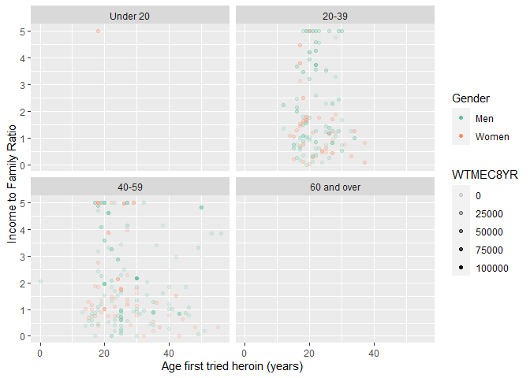

```r
ggplot(table_nhanes_1, aes(x = DUQ300,
                           y = INDFMPIR,
                                     color = Gender,
                                     alpha = WTMEC8YR)) +
  geom_point(na.rm = TRUE) +
  scale_color_brewer(palette = "Set2") +
  ylab("Income to Family Ratio") +
  xlab("Age first tried heroin (years)") +
  facet_wrap(~Age.Group)
```

**Description of above:** *Darker shading in dot plots indicates more heavily-weighted data points. Histogram “counts” are weighted.* Only one participant under 20 years reported age at first using heroin. Relative to marijuana and cocaine, a smaller number of participants (total n = 285) reported their age when they first tried heroin. Similar to marijuana and cocaine, more men (n = 190) than women (n = 95) responded. Overall average age at first trying heroin was ~24 yrs, about 7 and 3 years older than for marijuana and cocaine, respectively, as shown above. On average, and dissimilar to marijuana and cocaine, respectively, women were slightly younger than men. Similar to marijuana and cocaine, average age at first trying heroin decreased as age group decreased. Interestingly, the histograms show that older participants, especially men, reported first trying heroin at older ages including 30s, 40s and even 50s. The scatterplots demonstrate a relationship between income:family size ratio (lower ratios indicate greater poverty) in which older participants 20-59 years with greater poverty report first age at trying heroin at both younger and older ages relative to those at lower poverty levels, similar to cocaine use.

```r
# D) Age first tried meth (DUQ340)

table_nhanes_1 <- table_2011_2018 %>%
  mutate(DUQ340 = replace(DUQ340, DUQ340 >= 777, NA)) %>%
  #create factor variables
  mutate(# create indicator for overall summary
    table_nhanes_1 = 1,
    Year = factor(SDDSRVYR, labels = c("2011-2012", "2013-2014",
                                       "2015-2016", "2017-2018")),
    Gender = factor(RIAGENDR, labels=c("Men", "Women")),
    Age.Group = cut(RIDAGEYR, breaks=c(-Inf,19,39,59,Inf),
                    labels=c("Under 20", "20-39","40-59","60 and over")),
    # Generate 8-year MEC weight (Divide weight by 4 because we are
    #appending 4 survey cycles)
    # Note: using the MEC Exam Weights (WTMEC2YR), per the analytic notes
    #on the NHANES documentation
    WTMEC8YR = WTMEC2YR/4,
    # Define indicator for analysis population of interest: DUQ340 with a
    #valid age
    inAnalysis = (!is.na(DUQ340)))

NHANES_all_2 <- as_survey_design(table_nhanes_1, id=SDMVPSU, strata=SDMVSTRA,
                                 weights=WTMEC8YR, nest=TRUE)

NHANES_DUQ340 <- subset(NHANES_all_2, inAnalysis)
```

```r
# Weighted data descriptive statistics and visualizations

getSummary <- function(varformula, byformula, design){
  # Get mean, stderr, and unweighted sample size
  c <- svyby(varformula, byformula, design, unwtd.count )
  p <- svyby(varformula, byformula, design, svymean)
  outSum <- left_join(select(c,-se), p)
  outSum
}

# Get results (see output for all results tables and plots)

#DUQ340 weighted mean overall

getSummary(~DUQ340, ~table_nhanes_1, NHANES_DUQ340)
```

```
##   table_nhanes_1 counts   DUQ340        se
## 1              1    900 22.01556 0.3197709
```

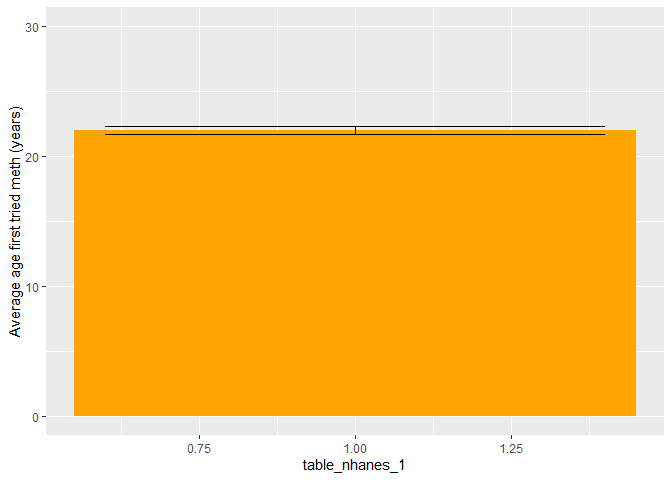

```r
out <- svyby(formula = ~DUQ340,
             by = ~table_nhanes_1,
             design = NHANES_DUQ340,
             FUN = svymean,
             na.rm = TRUE,
             keep.names = FALSE)

out_col <- mutate(out,
                  lower = DUQ340 - 1*se,
                  upper = DUQ340 + 1*se)

ggplot(out_col, aes(table_nhanes_1, DUQ340,
                    ymin = lower,
                    ymax = upper)) +
  geom_col(fill = "orange") +
  ylab("Average age first tried meth (years)") +
  geom_errorbar(width = 0.8) +
  ylim(NA,30)
```

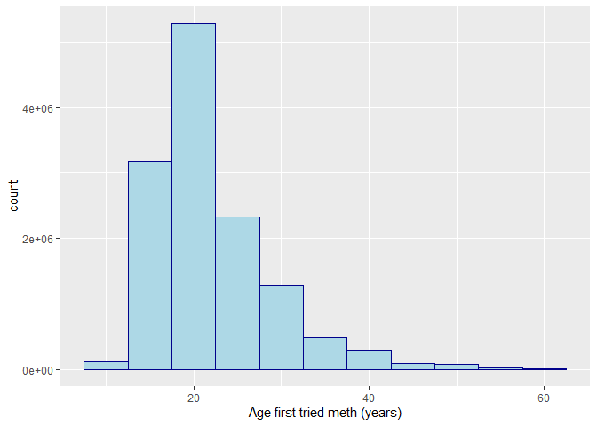

```r
ggplot(table_nhanes_1, aes(x = DUQ340, weight = WTMEC8YR)) +
  geom_histogram(binwidth = 5, color = "darkblue",
                 fill = "lightblue",
                 na.rm = TRUE)+
  xlab("Age first tried meth (years)")
```

```r
# By Gender
getSummary(~DUQ340, ~Gender, NHANES_DUQ340)
```

```
##   Gender counts   DUQ340        se
## 1    Men    588 22.19434 0.3468977
## 2  Women    312 21.67210 0.5626809
```

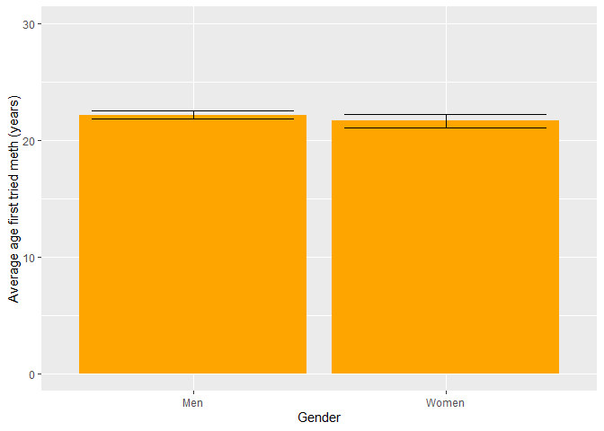

```r
out <- svyby(formula = ~DUQ340,
             by = ~Gender,
             design = NHANES_DUQ340,
             FUN = svymean,
             na.rm = TRUE,
             keep.names = FALSE)

out_col <- mutate(out,
                  lower = DUQ340 - 1*se,
                  upper = DUQ340 + 1*se)

ggplot(out_col, aes(x = Gender, y = DUQ340,
                    ymin = lower,
                    ymax = upper)) +
  geom_col(fill = "orange") +
  ylab("Average age first tried meth (years)") +
  geom_errorbar(width = 0.8) +
  ylim(NA,30)
```

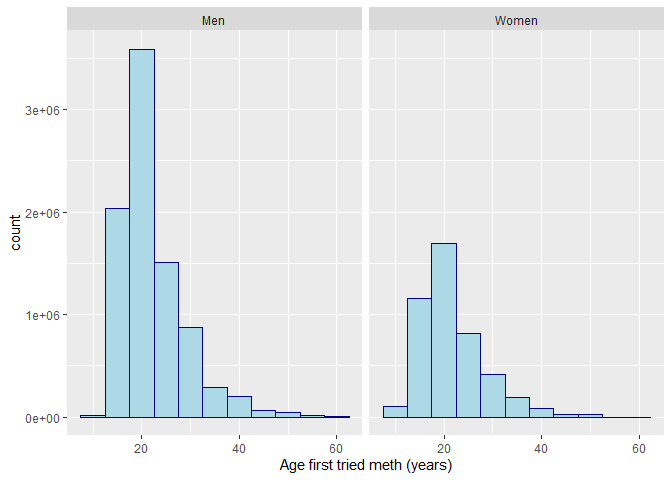

```r
ggplot(table_nhanes_1, aes(x = DUQ340, weight = WTMEC8YR)) +
  geom_histogram(binwidth = 5, color = "darkblue",
                 fill = "lightblue",
                 na.rm = TRUE) +
  facet_wrap(~Gender) +
  xlab("Age first tried meth (years)")
```

```r
# By Age
getSummary(~DUQ340, ~Age.Group, NHANES_DUQ340)
```

```
##   Age.Group counts   DUQ340        se
## 1  Under 20     12 16.62381 0.6661040
## 2     20-39    402 20.43651 0.2876035
## 3     40-59    486 23.08935 0.4841990
```

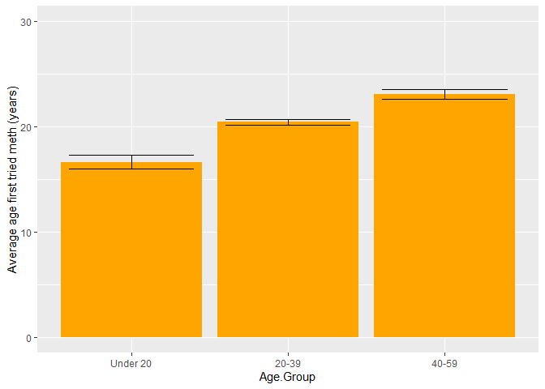

```r
out <- svyby(formula = ~DUQ340,
             by = ~Age.Group,
             design = NHANES_DUQ340,
             FUN = svymean,
             na.rm = TRUE,
             keep.names = FALSE)

out_col <- mutate(out,
                  lower = DUQ340 - 1*se,
                  upper = DUQ340 + 1*se)

ggplot(out_col, aes(x = Age.Group, y = DUQ340,
                    ymin = lower,
                    ymax = upper)) +
  geom_col(fill = "orange") +
  ylab("Average age first tried meth (years)") +
  geom_errorbar(width = 0.8) +
  ylim(NA,30)
```

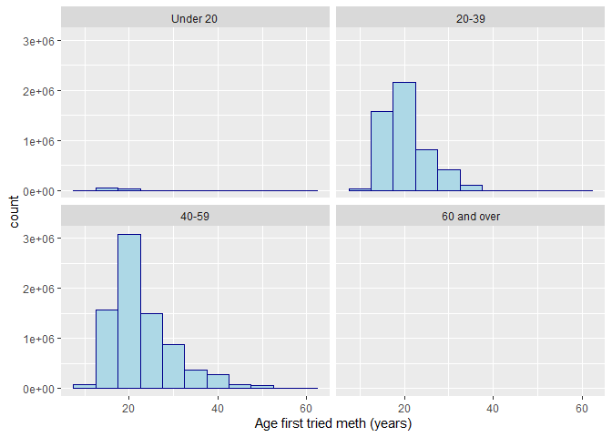

```r
ggplot(table_nhanes_1, aes(x = DUQ340, weight = WTMEC8YR)) +
  geom_histogram(binwidth = 5, color = "darkblue",
                 fill = "lightblue",
                 na.rm = TRUE) +
  facet_wrap(~Age.Group) +
  xlab("Age first tried meth (years)")
```

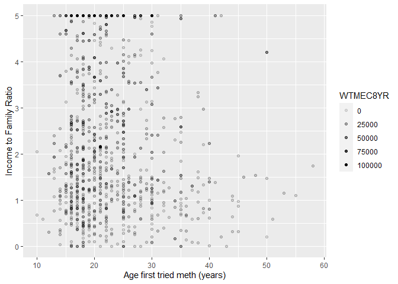

```r
################Relationship to Income:Family size ratio#######################

ggplot(table_nhanes_1, aes(x = DUQ340,
                                     y = INDFMPIR,
                                     alpha = WTMEC8YR)) +
  geom_point(na.rm = TRUE) +
  scale_color_brewer(palette = "Set2") +
  ylab("Income to Family Ratio") +
  xlab("Age first tried meth (years)")
```

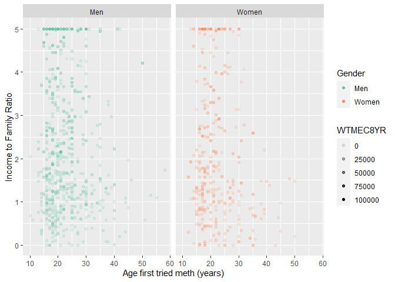

```r
ggplot(table_nhanes_1, aes(x = DUQ340,
                                     y = INDFMPIR,
                                     color = Gender,
                                     alpha = WTMEC8YR)) +
  geom_point(na.rm = TRUE) +
  scale_color_brewer(palette = "Set2") +
  ylab("Income to Family Ratio") +
  xlab("Age first tried meth (years)") +
  facet_wrap(~Gender)
```

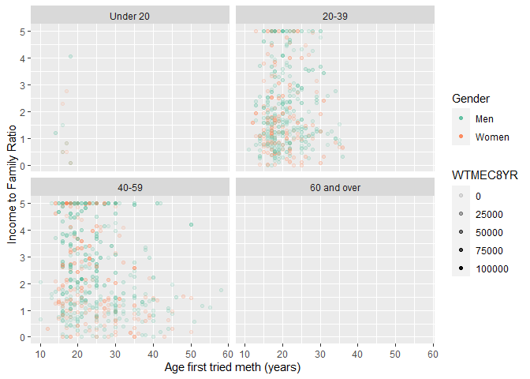

```r
ggplot(table_nhanes_1, aes(x = DUQ340,
                                     y = INDFMPIR,
                                     color = Gender,
                                     alpha = WTMEC8YR)) +
  geom_point(na.rm = TRUE) +
  scale_color_brewer(palette = "Set2") +
  ylab("Income to Family Ratio") +
  xlab("Age first tried meth (years)") +
  facet_wrap(~Age.Group)
```

**Description of above:** *Darker shading in dot plots indicates more heavily-weighted data points. Histogram “counts” are weighted.* Similar to other drugs, more men (n = 588) than women (n = 312) reported age at first using methamphetamine (meth). Only 12 participants under 20 years responded. Similar to cocaine, the overall average age at first trying meth was ~22 yrs. Similar to marijuana, cocaine, and heroin, average age at first trying meth decreased as age group decreased, implying that participants aged 20-39 and 40-59 tried meth at older ages than the under 20 participants who responded. Interestingly, similar to heroin, the histograms show that men and women reported first trying meth at older ages including 30s, 40s and even 50s. The scatterplots demonstrate a pattern in which men and women 20-59 years old report trying meth for the first time at older ages relative to their cohorts at lower poverty levels.

[output not shown]